# Reproducible Research Project 2

Amit Chitnis

May 14, 2016

# # Idetify the events that caused highest fatalities, injuries, property damage and crop damange based on NOAA database

================

## 1. SYNOPSIS

Weather is unpredictable, and when it is severe, it can be the cause of much misery. Being able to predict and prevent damage from severe weather events is a challenging task that required detailed study and interpretation of past occurrences.

The US National Oceanic and Atmospheric Administration (NOAA)’s storm database provides information about a variety of severe weather events like major storms, tornadoes, typhoons and cyclones in the history of the United States. There are specific details about each kind of event, such as time lines and locations, damage, loss of life and property.

This project takes an in-depth look at the details of the database to provide reports on the effect of such severe weather events in an effort to help minimize the resulting destruction.

The report takes a overhead approach to this issue by considering the ten most destructive weather events (in terms of fatalities, injuries, property and material damage) and plotting them on a bar chart. This process helped isolate **tornadoes** as being the most destructive in terms of fatalities and injuries.The **floods** are responsible for the highest property damages and **drought** caused the most crop damages.

## 2. Data Processing

The data for this assignment come in the form of a comma-separated-value file compressed via the bzip2 algorithm to reduce its size. You can download the file from the course web site:

[Storm Data](https://d396qusza40orc.cloudfront.net/repdata%2Fdata%2FStormData.csv.bz2) File Size: 47Mb There is also some documentation of the database available. Here you will find how some of the variables are constructed/defined.

National Weather Service Storm Data Documentation National Climatic Data Center Storm Events FAQ The events in the database start in the year 1950 and end in November 2011. In the earlier years of the database there are generally fewer events recorded, most likely due to a lack of good records. More recent years should be considered more complete.

“read.CSV” is used to load the data.

```r
data <- read.csv("repdata-data-StormData.csv")
```

Only relevant columns are selected for further analysis

```r
#Make a copy of dataframe for analysis and select the relevant columns
dataMod <- data[, c("EVTYPE","FATALITIES", "INJURIES", "PROPDMG", "PROPDMGEXP", "CROPDMG", "CROPDMGEXP")]
```

### Converting Factor variables into actual values

#### Find unique factor variables for Property Damage

```r
#Find exponential indicators for Property damange
unique(dataMod$PROPDMGEXP)
```

```
##  [1] K M   B m + 0 5 6 ? 4 2 3 h 7 H - 1 8
## Levels:  - ? + 0 1 2 3 4 5 6 7 8 B h H K m M
```

#### Convert factors used for Property Damage into actual values

```r
# Convert exponential indicators to actual values and store them in new PROPEXP column
# invalid indicators - ? +
dataMod$PROPEXP[dataMod$PROPDMGEXP == "+"] <- 0
dataMod$PROPEXP[dataMod$PROPDMGEXP == "-"] <- 0
dataMod$PROPEXP[dataMod$PROPDMGEXP == "?"] <- 0
# valid numeral indicators 0 1 2 3 4 5 6 7 8
dataMod$PROPEXP[dataMod$PROPDMGEXP == "0"] <- 1
dataMod$PROPEXP[dataMod$PROPDMGEXP == "1"] <- 10
dataMod$PROPEXP[dataMod$PROPDMGEXP == "2"] <- 100
dataMod$PROPEXP[dataMod$PROPDMGEXP == "3"] <- 1000
dataMod$PROPEXP[dataMod$PROPDMGEXP == "4"] <- 10000
dataMod$PROPEXP[dataMod$PROPDMGEXP == "5"] <- 100000
dataMod$PROPEXP[dataMod$PROPDMGEXP == "6"] <- 1000000
dataMod$PROPEXP[dataMod$PROPDMGEXP == "7"] <- 10000000
dataMod$PROPEXP[dataMod$PROPDMGEXP == "8"] <- 100000000
#valid alpha indicators B h H K m M
dataMod$PROPEXP[dataMod$PROPDMGEXP == "B"] <- 1e+09
dataMod$PROPEXP[dataMod$PROPDMGEXP == "h"] <- 100
dataMod$PROPEXP[dataMod$PROPDMGEXP == "H"] <- 100
dataMod$PROPEXP[dataMod$PROPDMGEXP == "K"] <- 1000
dataMod$PROPEXP[dataMod$PROPDMGEXP == "m"] <- 1e+06
dataMod$PROPEXP[dataMod$PROPDMGEXP == "M"] <- 1e+06
```

#### Update Property Damage column with actual values

```r
# Updating  PROPDMG column with actual values
dataMod$PROPDMG <- dataMod$PROPDMG * dataMod$PROPEXP
```

Now, repeat the steps for Crop damage factor variables

#### Find unique factor variables for Crop Damage

```r
#Find exponential indicators for Crop damange
unique(dataMod$CROPDMGEXP)
```

```
## [1]   M K m B ? 0 k 2
## Levels:  ? 0 2 B k K m M
```

#### Convert factors used for Crop Damage into actual values

```r
# invalid indicators ?
dataMod$CROPEXP[dataMod$CROPDMGEXP == "?"] <- 0
# valid numeral indicators 0 2
dataMod$CROPEXP[dataMod$CROPDMGEXP == "0"] <- 1
dataMod$CROPEXP[dataMod$CROPDMGEXP == "2"] <- 100
#valid alpha indicators k K m M
dataMod$CROPEXP[dataMod$CROPDMGEXP == "k"] <- 1000
dataMod$CROPEXP[dataMod$CROPDMGEXP == "K"] <- 1000
dataMod$CROPEXP[dataMod$CROPDMGEXP == "m"] <- 1e+06
dataMod$CROPEXP[dataMod$CROPDMGEXP == "M"] <- 1e+06
```

#### Update Crop Damage column with actual values

```r
# Updating  CROPDMG column with actual values
dataMod$CROPDMG <- dataMod$CROPDMG * dataMod$CROPEXP
```

### Calculate agreegate values per event type for Fatalities, Injuries, Property damage and Crop Damage

SQLDF library is used to identify the events with the highest fatalities, injuries, property damage and crop damage. #### Load SQLDF library

```r
#load SQLDF package
library(sqldf)
```

#### Write appropriate SQL statements to load dataframes

Group by clause and Sum functions are used to agreegate appropriate columns. Top 10 values for plotting purposes. Additionally USD figures are converted into billions for ease of understanding.

```r
#group records by EVTYPE and order by FATALITIE
dfFatalalies = sqldf("select EVTYPE, SUM(FATALITIES) as FATALITIES from `dataMod` group by EVTYPE order by FATALITIES desc")
#select top 10 rows for analysis
dfFatalalies=dfFatalalies[1:10,]
#group records by EVTYPE and order by INJURIES
dfInjuries = sqldf("select EVTYPE, SUM(INJURIES) as  INJURIES from `dataMod` group by EVTYPE order by INJURIES desc")
#select top 10 rows for analysis
dfInjuries=dfInjuries[1:10,]

#group records by EVTYPE and order by PROPDMG - Property Damage
dfPropDmg = sqldf("select EVTYPE, SUM(PROPDMG) as PROPDMG from `dataMod` group by EVTYPE order by PROPDMG desc")
#select top 10 rows for analysis
dfPropDmg=dfPropDmg[1:10,]
dfPropDmg = transform(dfPropDmg, PROPDMG = PROPDMG / 1000000000)
#group records by EVTYPE and order by CROPDMG - Crop Damage
dfCropDmg = sqldf("select EVTYPE, SUM(CROPDMG) as CROPDMG from `dataMod` group by EVTYPE order by CROPDMG desc")
#select top 10 rows for analysis
dfCropDmg=dfCropDmg[1:10,]
dfCropDmg = transform(dfCropDmg, CROPDMG = CROPDMG / 1000000000)
```

## Results

### Fatalities and Injuries

Histograms are prepared for to identify the event with highest fatalities and injuries. The events with the highest values are plotted in a red colored bar. The plots clearly identify **Tornadoes** are the most destructive in terms of fatalities and injuries.

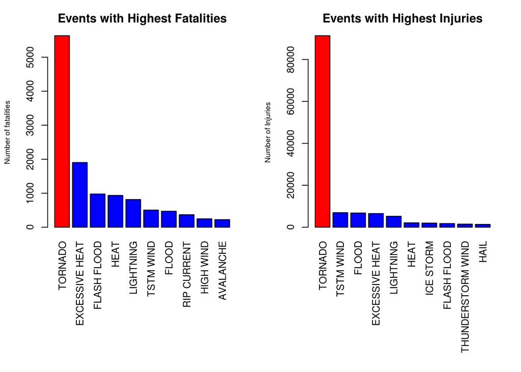

```r
#Plot Fatalities and Injuries plot together
par(mfrow = c(1, 2), mar = c(12, 4, 3, 2), mgp = c(3, 1, 0), cex = 0.8)
#Display the event with the highest fatalities in red and others in blue
cols <- c("blue", "red")[(dfFatalalies$FATALITIES == max(dfFatalalies$FATALITIES)) + 1]
barplot(dfFatalalies$FATALITIES, las = 3, names.arg = dfFatalalies$EVTYPE, main = "Events with Highest Fatalities",
        ylab = "Number of fatalities", col = cols,  col.lab="black", cex.lab=0.75)

#Display the event with the highest Injuries in red and others in blue
cols <- c("blue", "red")[(dfInjuries$INJURIES == max(dfInjuries$INJURIES)) + 1]
barplot(dfInjuries$INJURIES, las = 3, names.arg = dfInjuries$EVTYPE, main = "Events with Highest Injuries",
        ylab = "Number of Injuries", col = cols,  col.lab="black", cex.lab=0.75)
```

### Property Damage and Crop Damange Histograms are prepared for to identify the event with highest property and crop damages. USD figures are in billions. The events with the highest values are plotted in a red colored bar. The plots clearly identify **Flood** as the most destructive event for property damages and **Drought** as the most destructive for crop damages.

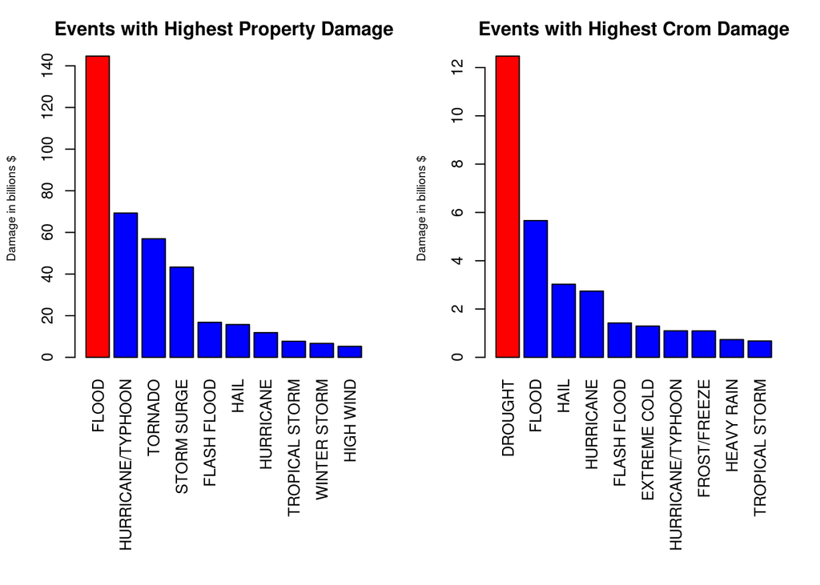

```r
#Plot Property damage and Crop damage plots together
par(mfrow = c(1, 2), mar = c(12, 4, 3, 2), mgp = c(3, 1, 0), cex = 0.8)
cols <- c("blue", "red")[(dfPropDmg$PROPDMG == max(dfPropDmg$PROPDMG)) + 1]

barplot(dfPropDmg$PROPDMG, las = 3, names.arg = dfPropDmg$EVTYPE, main = "Events with Highest Property Damage",
        ylab = "Damage in billions $", col = cols,  col.lab="black", cex.lab=0.75)

cols <- c("blue", "red")[(dfCropDmg$CROPDMG == max(dfCropDmg$CROPDMG)) + 1]
barplot(dfCropDmg$CROPDMG, las = 3, names.arg = dfCropDmg$EVTYPE, main = "Events with Highest Crom Damage",
        ylab = "Damage in billions $", col = cols,  col.lab="black", cex.lab=0.75)
```